# Analyses of GSE99304

## Volcano Length

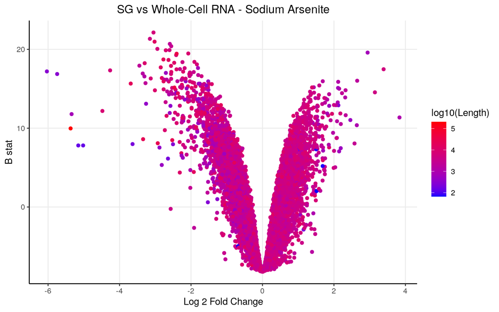

```r
ggplot(data=DEGenes,
                 aes(x=logFC,
                     y=  B)) +
  geom_point(aes(color=log10(Length)))+
  theme_bw() +
  theme(axis.line = element_line(colour = "black"),
        panel.grid.minor = element_blank(),
        panel.border = element_blank(),
        panel.background = element_blank()) +
  ggtitle("SG vs Whole-Cell RNA - Sodium Arsenite")+ ylab("B stat")+xlab("Log 2 Fold Change") +
  theme(plot.title = element_text(hjust = 0.5))  +
  scale_colour_gradient(low = "blue", high = "red")
```

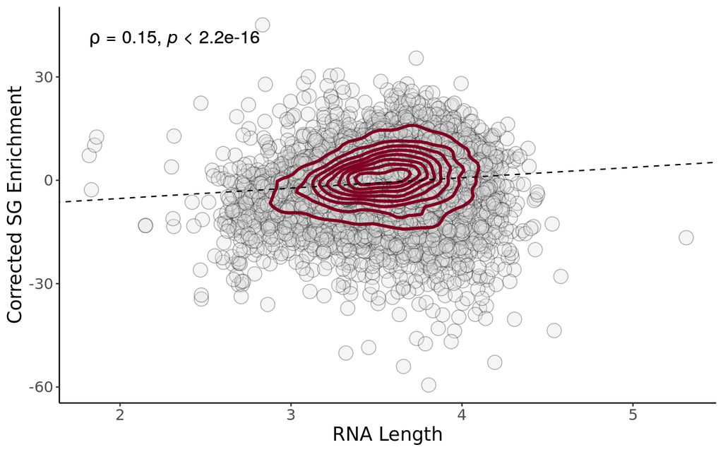

```r
smooth.SG <- lm(t~log10(Length), DEGenes)
liner.SG <- rstandard(smooth.SG)
DEGenes <-cbind(DEGenes, liner.SG)
colnames(DEGenes)[11] <- "Residuals"
row.names(DEGenes) <- DEGenes$Gene

linemarkers <- rbind(upmarkers, downmarkers)
linemarkers <- DEGenes[DEGenes$Gene %in% row.names(linemarkers),]

# Calculate the Spearman correlation coefficient
spearman_corr <- cor(DEGenes$t, log10(DEGenes$Length), method = "spearman")


firstsimcentri <- ggplot(DEGenes, aes(y=t, x=log10(Length))) +
  geom_point(fill = "#DDDDDD", alpha = 0.3, size=5, shape=21, colour='black') +
  geom_density2d(color="#800020", size=1.2)+ theme_bw()+
 xlab("RNA Length") + ylab("Corrected SG Enrichment") +
  theme(axis.line = element_line(colour = "black"),
        panel.grid.minor = element_blank(),
        panel.border = element_blank(),
        panel.background = element_blank()) +
  theme(plot.title = element_text(hjust = 0.5))  +
  geom_abline(slope=smooth.SG$coefficients[2], intercept = smooth.SG$coefficients[1], linetype = "dashed")+ stat_cor(method = "spearman", cor.coef.name = "rho", size=5)+
  theme(text=element_text(size=15,  family="Arial MS")) + stat_cor(method = "spearman", cor.coef.name = "rho", size=5)+ theme(panel.grid.major = element_blank(), panel.grid.minor = element_blank())

#tiff("~/Projects/StressGranules/SGPAPER/Figure3A.tiff", width = 7, height=4, units = "in", res=300)
firstsimcentri
```

```r
#dev.off()
```

## GSEA Enrichment

Now that we have our genes of interest, it would also be interesting to see what are the **altered pathways** between enriched and depleted RNAs from the stress granules. Therefore, lets perform a *Gene Set Enrichment Analysis*

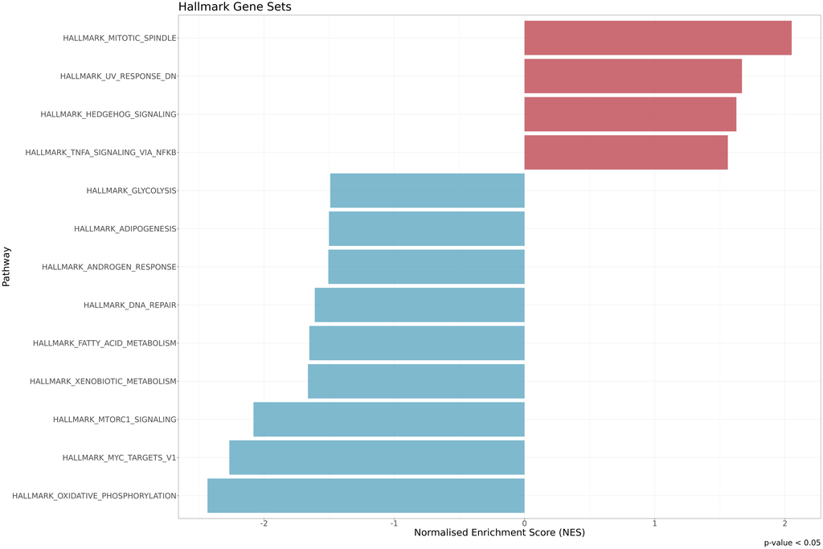

```r
#for all genes
DEGenes <- DEGenes[order(DEGenes[,4]),]
gseatool <- DEGenes[,4]
gseatool <- as.data.frame(gseatool)
colnames(gseatool)[1] <- "t"
gseatool[,2] <- DEGenes$Gene
colnames(gseatool)[2] <- "Symbol"
gseatool <- gseatool[,c(2,1)]

#for only the genes without the contamination


vectorranks <- gseatool$t
names(vectorranks) <- gseatool$Symbol


#to load our pathways
hallmarks.gs <- msigdbr(species = "Homo sapiens", collection = "H")

hallmarks.gsets <- hallmarks.gs %>% split(x = .$gene_symbol, f = .$gs_name)

for (set in names(hallmarks.gsets)){
  hallmarks.gsets[[set]] <- toupper(hallmarks.gsets[[set]])
}

hallmarks.res <- fgsea(pathways = hallmarks.gsets,
                       stats = vectorranks)

hallmarks.res.tidy <- hallmarks.res %>%
  as_tibble() %>%
  arrange(desc(NES))

hallmarks.res.tidy %>%
  dplyr::select(-leadingEdge, -ES) %>%
  arrange(padj)

hallmark.sg.t <- hallmarks.res.tidy[,c(1,6)]
hallmark.sg.t <- as.data.frame(hallmark.sg.t)

#this small part is generic
thresh <- 0.05

#this one is no longer generic
data_to_plot <- hallmarks.res.tidy %>% filter(padj < thresh)

statvec <- c()
for (i in 1:nrow(data_to_plot)){
  if (data_to_plot[i,6] > 0){
    status <- "Upregulated"
  }
 else {
   status <- "Downregulated"
 }
statvec <- c(statvec, status)
}

data_to_plot$Status <- statvec

##-----HALMARK-----
gsea_plot_hall <- ggplot(data_to_plot, aes(reorder(pathway, NES), NES)) +
  geom_col(aes(fill= Status), alpha=0.75) + scale_fill_manual(values = c("#53A2BE","#BA3B46"), name = "Regulation Status", labels = c("Downregulated", "Upregulated"), breaks = c("Downregulated", "Upregulated")) +
  coord_flip() +
  labs(x="Pathway", y="Normalised Enrichment Score (NES)",
       title= "Hallmark Gene Sets",
       caption = paste0("p-value < ", thresh)) + theme(plot.title = element_text(hjust = 1)) +
  theme_bw() + theme(text=element_text(family = "Quicksand")) + theme(legend.position = "none")


gsea_plot_hall+
  theme(text=element_text(size=25,  family="Arial MS"))
```

### For Mito

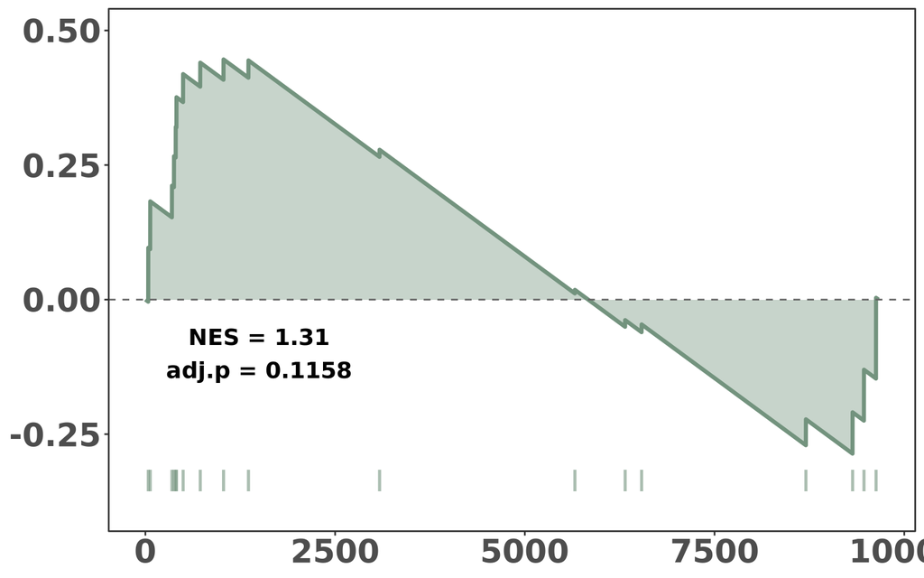

```r
# --- Rank genes by t-statistic as usual ---
DEGenes <- DEGenes[order(DEGenes[,4]),]
gseatool <- DEGenes[,4]
gseatool <- as.data.frame(gseatool)
colnames(gseatool)[1] <- "t"
gseatool[,2] <- DEGenes$Gene
colnames(gseatool)[2] <- "Symbol"
gseatool <- gseatool[,c(2,1)]
vectorranks <- gseatool$t
names(vectorranks) <- gseatool$Symbol

# --- Define MitoGenes as a custom gene set ---
MitoGenes <- fread("~/MitoGenes.txt")[[1]]
custom.gsets <- list(MitoGenes = toupper(MitoGenes))

# --- Run fgsea ---
mito.res <- fgsea(pathways = custom.gsets,
                  stats = vectorranks)

mito.plot.base <- plotEnrichment(custom.gsets[["MitoGenes"]], vectorranks)
curve.data <- mito.plot.base$data

# --- key fix: match the curve's internal descending order ---
ord <- order(vectorranks, decreasing = TRUE)
ranked.names <- names(vectorranks)[ord]
gene.positions <- which(ranked.names %in% custom.gsets[["MitoGenes"]])

rug.top    <- min(curve.data$y) - 0.03
rug.bottom <- rug.top - 0.04

y.min <- rug.bottom - 0.03
y.max <- max(curve.data$y) + 0.05

(mito.plot <- ggplot(curve.data, aes(x = x, y = y)) +
  geom_area(fill = "#73937E", alpha = 0.4) +
  geom_line(color = "#73937E", linewidth = 1.2) +
  geom_hline(yintercept = 0, linetype = "dashed", color = "grey40") +
  geom_segment(data = data.frame(x = gene.positions),
               aes(x = x, xend = x, y = rug.top, yend = rug.bottom),
               color = "#73937E", alpha = 0.6, linewidth = 0.9,
               inherit.aes = FALSE) +
  annotate("text", x = 1500, y = -0.1,
           label = paste0("NES = ", round(mito.res$NES, 2),
                          "\nadj.p = ", round(mito.res$padj, 4)),
           size = 5, family = "Arial MS", fontface = "bold") +
  coord_cartesian(ylim = c(y.min, y.max), clip = "off") +
  theme_bw() +
  theme(text = element_text(size = 25, family = "Arial MS"),
        plot.title = element_text(hjust = 0.5, face = "bold"),
        axis.title = element_blank(),
        axis.text = element_text(face = "bold"),
        panel.grid.minor = element_blank(),
        panel.grid.major = element_blank()))
```

```r
png("~/Projects/StressGranules/SGPAPER/Images/PNG/MitoGSEA_Khong.png", width=7, height=6, units="in", res=300)
mito.plot
dev.off()
```

### For Nuc

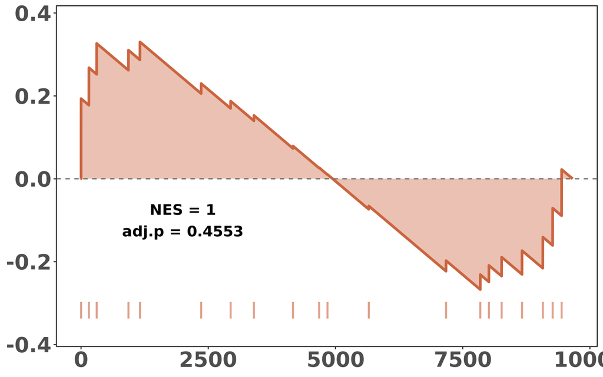

```r
# --- Rank genes by t-statistic as usual ---
DEGenes <- DEGenes[order(DEGenes[,4]),]
gseatool <- DEGenes[,4]
gseatool <- as.data.frame(gseatool)
colnames(gseatool)[1] <- "t"
gseatool[,2] <- DEGenes$Gene
colnames(gseatool)[2] <- "Symbol"
gseatool <- gseatool[,c(2,1)]
vectorranks <- gseatool$t
names(vectorranks) <- gseatool$Symbol

# --- Define MitoGenes as a custom gene set ---
MitoGenes <- fread("~/rnalocate_mito_filt.csv")[[1]]
custom.gsets <- list(MitoGenes = toupper(MitoGenes))

# --- Run fgsea ---
mito.res <- fgsea(pathways = custom.gsets,
                  stats = vectorranks)

mito.plot.base <- plotEnrichment(custom.gsets[["MitoGenes"]], vectorranks)
curve.data <- mito.plot.base$data

# --- key fix: match the curve's internal descending order ---
ord <- order(vectorranks, decreasing = TRUE)
ranked.names <- names(vectorranks)[ord]
gene.positions <- which(ranked.names %in% custom.gsets[["MitoGenes"]])

rug.top    <- min(curve.data$y) - 0.03
rug.bottom <- rug.top - 0.04

y.min <- rug.bottom - 0.03
y.max <- max(curve.data$y) + 0.05

(mito.plot <- ggplot(curve.data, aes(x = x, y = y)) +
  geom_area(fill = "#CB643F", alpha = 0.4) +
  geom_line(color = "#CB643F", linewidth = 1.2) +
  geom_hline(yintercept = 0, linetype = "dashed", color = "grey40") +
  geom_segment(data = data.frame(x = gene.positions),
               aes(x = x, xend = x, y = rug.top, yend = rug.bottom),
               color = "#CB643F", alpha = 0.6, linewidth = 0.9,
               inherit.aes = FALSE) +
  annotate("text", x = 2000, y = -0.1,
           label = paste0("NES = ", round(mito.res$NES, 2),
                          "\nadj.p = ", round(mito.res$padj, 4)),
           size = 5, family = "Arial MS", fontface = "bold") +
  coord_cartesian(ylim = c(y.min, y.max), clip = "off") +
  theme_bw() +
  theme(text = element_text(size = 25, family = "Arial MS"),
        plot.title = element_text(hjust = 0.5, face = "bold"),
        axis.title = element_blank(),
        axis.text = element_text(face = "bold"),
        panel.grid.minor = element_blank(),
        panel.grid.major = element_blank()))
```

```r
png("~/Projects/StressGranules/SGPAPER/Images/PNG/NucGSEA_Khong.png", width=7, height=6, units="in", res=300)
mito.plot
dev.off()
```

# Comparison Between Original and Simulated Enrichment

Is the SpinSim pipeline, which only takes centrifugation into account, a good recapitulation of DC’s SG enrichment? Here, I directly check this.

```r
cor_sim_df <- merge(simulatedenrichment, originalenrichment, by="Gene")
cor_sim_df <- merge(cor_sim_df, genelength, by="Gene")


smooth.SG <- lm(sim_t ~ og_t, cor_sim_df)
liner.SG <- rstandard(smooth.SG)
cor_sim_df <-cbind(cor_sim_df, liner.SG)
colnames(cor_sim_df)[9] <- "Residuals"
row.names(cor_sim_df) <- cor_sim_df$Gene
linemarkers <- as.data.frame(cor_sim_df[abs(cor_sim_df$Residuals)>4,])

cor.test(cor_sim_df$sim_t, cor_sim_df$og_t, method="spearman")
```

```
##
##  Spearman's rank correlation rho
##
## data:  cor_sim_df$sim_t and cor_sim_df$og_t
## S = 4.2073e+10, p-value < 2.2e-16
## alternative hypothesis: true rho is not equal to 0
## sample estimates:
##       rho
## 0.7199547
```

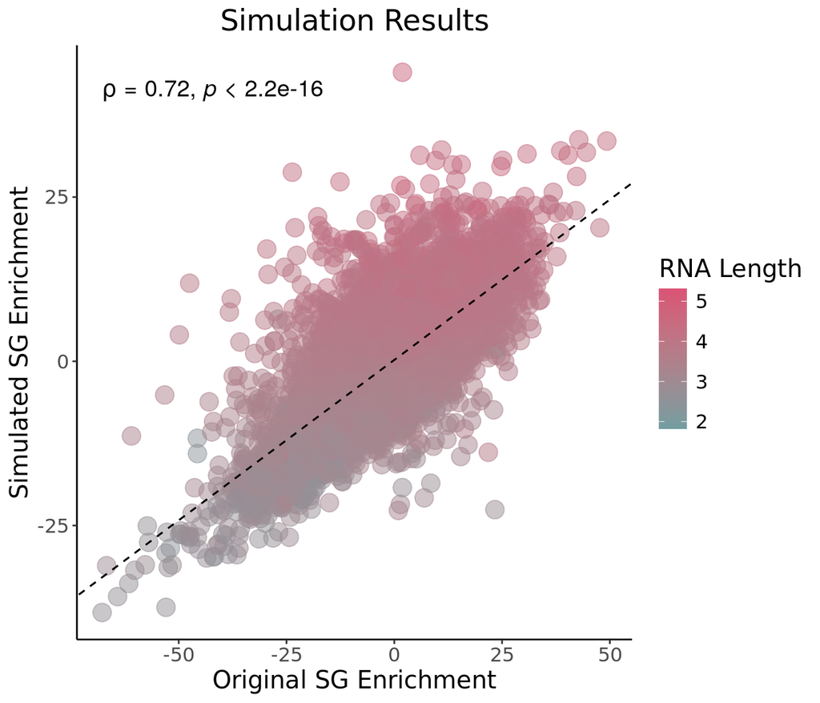

```r
SimCorrel <- ggplot(cor_sim_df, aes(x=og_t, y=sim_t)) + geom_point(aes(colour=log10(Length)),alpha=0.5, size=5) +   theme_bw()+
 xlab("Original SG Enrichment") + ylab("Simulated SG Enrichment") +
  theme(axis.line = element_line(colour = "black"),
        panel.grid.minor = element_blank(),
        panel.border = element_blank(),
        panel.background = element_blank()) + ggtitle("Simulation Results")+
  theme(plot.title = element_text(hjust = 0.5))  +
  geom_abline(slope=smooth.SG$coefficients[2], intercept = smooth.SG$coefficients[1], linetype = "dashed")+
  theme(text=element_text(size=15,  family="Arial MS")) + stat_cor(method = "spearman", cor.coef.name = "rho", size=5) +
  theme(plot.title = element_text(hjust = 0.5)) +
  geom_abline(slope = smooth.SG$coefficients[2],
              intercept = smooth.SG$coefficients[1],
              linetype = "dashed") + theme(panel.grid.major = element_blank(), panel.grid.minor = element_blank())+
  scale_colour_gradient(low="#729EA1", high = "#DB5375")+
  labs(colour = "RNA Length")

SimCorrel
```

```r
#tiff("../Projects/StressGranules/SGPAPER/SimCorrel.tiff", width = 8, height=6, units = "in", res=300)
#SimCorrel
#dev.off()
```

As we can see, there is a strong correlation, which implies that the hypothesis that the signal is mainly from centrifugation cannot be discarded.

[^1]: Disease Transcriptomics Group, Gulbenkian Institute of Molecular Medicine